# Home

##### About

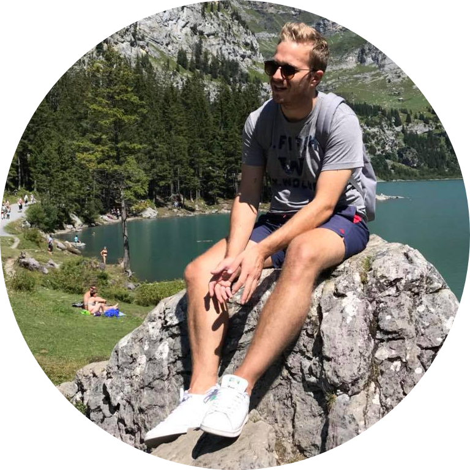

I am an Imperial Research College Fellow at [MRC Centre for Environment and Health](https://www.environment-health.ac.uk/) at Imperial College London, working on the impacts of temperature on health and methods for estimating excess mortality. My group is the [Environmental and Health Statistics group](https://sites.google.com/view/envstats/home) headed by [Prof Marta Blangiardo](https://www.imperial.ac.uk/people/m.blangiardo).

Before that, I was an MRC Skills Development Research Fellow at the Department of Epidemiology and Biostatistics, part of the [MRC Centre for Environment and Health](https://www.environment-health.ac.uk/) at Imperial College London.

Ι did my PhD in Biostatistics and Epidemiology at the [Institute of Social and Preventive Medicine](https://www.ispm.unibe.ch/) (ISPM) at the University of Bern in Switzerland in the [Environmental and Spatial Epidemiology group](https://www.ispm.unibe.ch/research/research_groups/environmental_and_spatial_epidemiology/index_eng.html) headed by [Dr Ben Spycher](https://www.ispm.unibe.ch/about_us/staff/spycher_ben/index_eng.html). Also, I obtained an MSc in Biostatistics at the University of Glasgow and BSc in Mathematics at the Aristotle University of Thessaloniki.

##### Education

- **2019** – PhD in Biostatistics and Epidemiology, University of Bern
- **2015** – Master in Biostatistics, University of Glasgow
- **2012** – Bachelor in Mathematics, Aristotle University of Thessaloniki

##### Research visits

- **2018** – King Abdullah University of Science and Technology to [Prof Haavard Rue](https://www.kaust.edu.sa/en/study/faculty/haavard-rue)
- **2017** – University of Gottingen to [Prof Dominic Schuhmacher](http://www.dominic.schuhmacher.name/)